# Population estimation example

Patrick Graham

31 August 2018

We will illustrate rejection sampling using the problem of estimating the number of trials in Binomial experiment with known success probability. This is the opposite problem to that usually encountered in Binomial experiments where the number of trials is known but the success probability is not. It is a simplified version of a problem arising in population estimation. The simplification is that usually the success probability needs to be estimated as well as the population size. Capture-recapture studies (known as dual-system estimation in official statistics) allow both the number of trials and the success probability (“capture probability”in this context) to be estimated. We assume the the capture probability is known. We let $X$ denote the observed count, $N$ the population size to be captured, and $\theta$ the known capture probability. Our model of the observed count is
$$X \sim \mathrm{Binomial}(N,\theta)$$
The likelihood for $N$ is
$$\begin{aligned}
p(X|N,\theta) & =\binom{N}{X}\theta^{X}(1-\theta)^{(N-X)} \\
& \propto \binom{N}{X}(1-\theta)^{(N-X)}
\end{aligned}$$
Consequently the log-likelihood is
$$l(X|N,\theta) = \log(\binom{N}{X}) (N-X) \log(1-\theta)$$
The prior for $N$ is a discrete uniform on the interval $(4000,6000).$ The observed data is X=4350.

```r
library(MASS)
library(MCMCpack)
#wd <- "C:/Users/Patrick/Documents/Patrick"   #change to your folder or hash out this and the following line
                                         #if you want to default to your own folder
#setwd(wd)
#set-up functions that are needed

##log pmf for N assuming a uniform prior - log-likelihood
logpN <- function(N,X,theta) {

  #logdens <- lfactorial(N) - (lfactorial(N-n) + lfactorial(n)) +
  # (N-n)*log(p0)
  logdens <- lchoose(N,X) +  (N-X)*log(1-theta)
  return(logdens)
}
```

check what happens for values of N < observed

```r
logpN(N=4000,X=4350,theta=0.87)
```

```
## [1] -Inf
```

```r
##so likelihood is
exp(logpN(N=4000,X=4350,theta=0.87))
```

```
## [1] 0
```

No support for population values less than the observed count - make sense.

[figure not shown]

Now we set-up the rejection sampler based on uniform prior Define a function to generate a single draw from the posterior

```r
acceptN <- function(X,theta,ntry,low=1,high=10000000) {

  # X is the observed count
  # theta - probability of capture
    #ntry is the maximum number of attempts at generating N
  ##lower bound of prior
  ##upper bound of prior

  ##calls the function logpN

    guess <- X/theta #MLE
  lower <- max((X+1),low)
    upper <- high
   max_logdens <- logpN(N=guess,X=X,theta=theta)

  accept <- 0
  attempt <- 1

  ##Define a vector of points on which the prior is defined
  testseq <- seq(from=lower,to=upper,by=1)

  while((accept < 1) & (attempt < (ntry + 1))) {
    Ntest <- sample(testseq,size=1)
    logpNtest <- logpN(N=Ntest,X=X,theta=theta)
    check <- logpNtest - max_logdens
    u <- runif(1,0,1)
    if (u <= exp(check))
    {accept <- 1}
    attempt <- attempt + 1
  }   #end while loop
  return(c(Ntest,attempt))
}  #End function
```

Now all we need to do is set the desired posterior sample size and run acceptN() in a loop to get the required number of values of $N$.

```r
npos <- 2000
possamp <- vector(mode="numeric",length=npos)
nattempts <- vector(mode="numeric",length=npos)
theta = 0.87
X  = 4350   ##observed sample size

for (i in 1:npos) {
  newN <- acceptN(X=4350,theta=0.87,ntry=5000,low=4000,high=6000)
 possamp[i] <- newN[1]
 nattempts[i] <- newN[2]
 }
summary(possamp)
```

```
##    Min. 1st Qu.  Median    Mean 3rd Qu.    Max.
##    4905    4981    5000    5000    5019    5108
```

```r
summary(nattempts)
```

```
##    Min. 1st Qu.  Median    Mean 3rd Qu.    Max.
##    2.00    9.00   18.00   24.71   34.00  203.00
```

plot posterior histogram

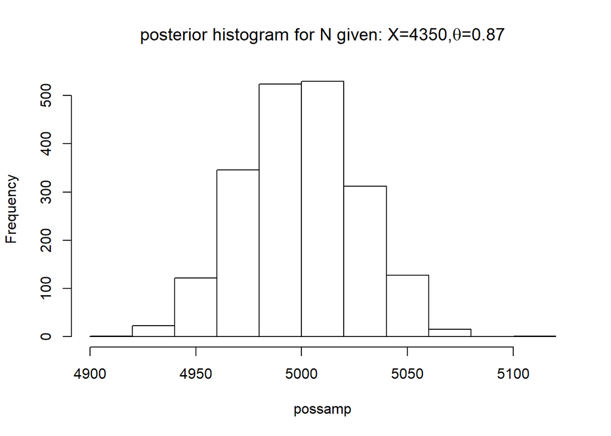

```r
hist(possamp,main=expression(paste("posterior histogram for N given: X=4350,",theta,"=0.87")))
```

Compare with true posterior percentiles

```r
##Define a vector of points on which the prior is defined
  testseq <- seq(from=4350,to=6000,by=1)
##evaluate the log-posterior at each point
logpost <- logpN(N=testseq,X=4350,theta=0.87)
head(logpost)
```

```
## [1]  0.00000  6.33794 11.98296 17.22275 22.17509 26.90451
```

```r
str(logpost)
```

```
##  num [1:1651] 0 6.34 11.98 17.22 22.18 ...
```

Get the cumulative distribution

```r
postdist <- exp(logpost)/(sum(exp(logpost)))
head(postdist)
```

```
## [1] 7.051283e-264 3.988417e-261 1.128243e-258 2.128206e-256 3.011517e-254
## [6] 3.409941e-252
```

```r
sum(postdist)
```

```
## [1] 1
```

```r
cumdist <- cumsum(postdist)
##set up indicators for the quantiles
q025 <- sum((cumdist <= 0.025))  ## number of points until 2.5 percentile
q50 <- sum((cumdist <= 0.5) )
q975 <- sum((cumdist <= 0.975) )
##can near get quantiles by locating these points on the list of possible of points -- this is like inverting the cumulative distribution function
Nlow <- testseq[q025]
Nmedian <- testseq[q50]
Nhigh <- testseq[q975]
true_quant <- c(Nlow,Nmedian,Nhigh)
reject_quant <- quantile(possamp,probs=c(0.025,0.5,0.975))
cat("true-quantiles",true_quant, "\n",sep=" ")
```

```
## true-quantiles 4946 4999 5053
```

```r
cat("quantiles estimated from rejection sampling,", reject_quant, "\n",sep=" ")
```

```
## quantiles estimated from rejection sampling, 4949 5000 5052
```

The approached to computing the “true” quantiles could be refined further to account of the discrete-ness.